# R ile Zaman Serileri Analizine Giriş

Finansal Ekonometri (MPİ-TYL YTÜ İktisat)

Prof. Dr. Hüseyin Taştan

Yıldız Technical University

2021 Spring

# 1 R’da Zaman serilerinin temsili

Bir zaman serisi kronolojik olarak sıralanmış (zaman ile endekslenmiş) ölçüm veya gözlemlerden oluşur. Çoğu zaman serisi birbirine eşit uzaklıktaki zaman dilimlerinde ölçülür (saatlik, günlük, haftalık, aylık, üç aylık, yıllık gibi). Ancak düzensiz ölçümlü zaman serileri ya da kayıp gözlemli zaman serileri de olabilir.

Zaman serileri tipik olarak finans ve makroekonomik analizlerde karşımıza çıkar. Bu alandaki önemli konulardan bir öngörüdür (forecasting). Öngörü problemlerinde geçmiş gözlem veya ölçümlerden hareketle geleceğin en az hata payıyla kestirilmesi amaçlanır. Örneğin merkez bankaları rutin olarak gelecekteki enflasyonu tahmin etmeye çalışır.

Zaman serileri ile ekonometrik analiz yapabilmek için kullandığımız yazılımın bu veri tipini tanıması ve anlaması gerekir. Her ekonometrik yazılım için verilerin zaman serisi olduğu ve sıklığının ne olduğunun (zaman değişkeninin ne olduğunun) tanıtılması gerekir. Açık kaynaklı bir yazılım olan `R`’da zaman serilerinin tanıtılması ve işlemlerin yapılması için çok çeşitli yaklaşımlar geliştirilmiştir. Aşağıda en popüler paket ve yaklaşımlar gözden geçirilmiştir. Daha fazla bilgi için bkz. [CRAN Task View: Time Series Analysis](https://cran.r-project.org/web/views/TimeSeries.html)

# 2 `ts` object

`ts` base `R` ile birlikte gelen `stats` paketinin bir parçasıdır. `ts` nesnesi ile eşit aralıklı (aylık, üç aylık, yıllık gibi) zaman serilerinin kolayca temsili mümkündür. Örneğin

```r
set.seed(1)
x <- rnorm(10)
x
```

```
##  [1] -0.6264538  0.1836433 -0.8356286  1.5952808  0.3295078 -0.8204684
##  [7]  0.4874291  0.7383247  0.5757814 -0.3053884
```

```r
class(x)
```

```
## [1] "numeric"
```

Rassal değişken `x`’in sınıfı (class) sayısaldır (numeric). Bu değişkeni 2010-2019 yılları ararasında gözlemlenmiş yıllık bir zaman serisi nesnesine (ts) dönüştürmek istersek:

```r
ts_yillik <- ts(x, start = 2010, frequency = 1)
ts_yillik
```

```
## Time Series:
## Start = 2010
## End = 2019
## Frequency = 1
##  [1] -0.6264538  0.1836433 -0.8356286  1.5952808  0.3295078 -0.8204684
##  [7]  0.4874291  0.7383247  0.5757814 -0.3053884
```

Burada `ts_yillik` nesnesi nümerik değerler alır ancak ek olarak zaman serisi özellikleri de taşır (attributes). `ts` nesnesinin başlangıcı, bitişi, ve frekansı (yıllık için 1) belirtilmiştir.

```r
class(ts_yillik)
```

```
## [1] "ts"
```

```r
attributes(ts_yillik)
```

```
## $tsp
## [1] 2010 2019    1
##
## $class
## [1] "ts"
```

`ts_yillik` vektörünün sınfı `ts`’dir. `tsp` sırasıyla başlangıç, bitiş tarihini ve frekansı gösterir.

Base `R`’ın `plot` fonksiyonu nesnenin sınıfını otomatik olarak algılar ve grafiği uygun olarak çizer:

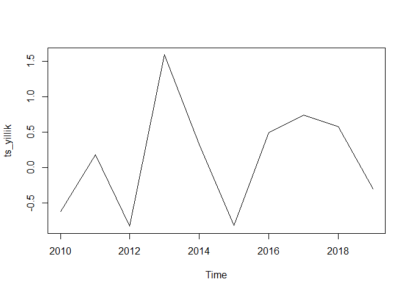

```r
plot(ts_yillik)
```

`plot` fonksiyonunu nümerik `x` vektörü ile kullanırsak:

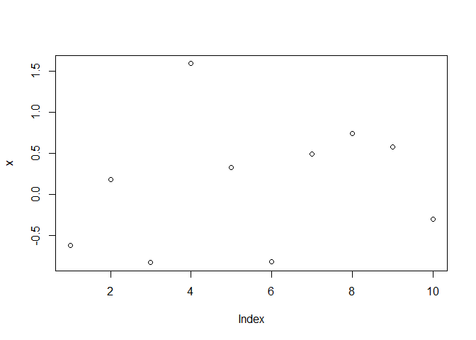

```r
plot(x)
```

Elimizde birden fazla zaman serisi varsa bunları ts özellikleri olan nümerik bir matris olarak tanımlayabiliriz. Örneğin aşağıdaki yapay olarak türetilmiş verileri düşünelim:

```r
set.seed(22)
n <- 120
x1 <- rnorm(n)
x2 <- rnorm(n)
t <- 1:n
y <- 10 + 0.1*t + 2*x1 - 3*x2 + rnorm(n)
df1 <- data.frame(y, x1, x2)
head(df1)
```

```
##          y         x1         x2
## 1 11.01752 -0.5121391 -0.6665832
## 2 17.13793  2.4851837 -0.3467479
## 3 14.11995  1.0078262 -0.4358330
## 4 16.11770  0.2928146 -1.9470039
## 5 11.83468 -0.2089594 -0.8379082
## 6 17.89354  1.8580924 -0.7415289
```

Bu verilerin aylık olduğunu ve 2010m1 döneminden başlağını ve 10 yılı kapsadığın varsayalım:

```r
ts_aylik <- ts(df1, start = c(2010, 1), end = c(2019, 12), frequency = 12)
head(ts_aylik)
```

```
##             y         x1         x2
## [1,] 11.01752 -0.5121391 -0.6665832
## [2,] 17.13793  2.4851837 -0.3467479
## [3,] 14.11995  1.0078262 -0.4358330
## [4,] 16.11770  0.2928146 -1.9470039
## [5,] 11.83468 -0.2089594 -0.8379082
## [6,] 17.89354  1.8580924 -0.7415289
```

```r
attributes(ts_aylik)
```

```
## $dim
## [1] 120   3
##
## $dimnames
## $dimnames[[1]]
## NULL
##
## $dimnames[[2]]
## [1] "y"  "x1" "x2"
##
##
## $tsp
## [1] 2010.000 2019.917   12.000
##
## $class
## [1] "mts"    "ts"     "matrix"
```

```r
class(ts_aylik)
```

```
## [1] "mts"    "ts"     "matrix"
```

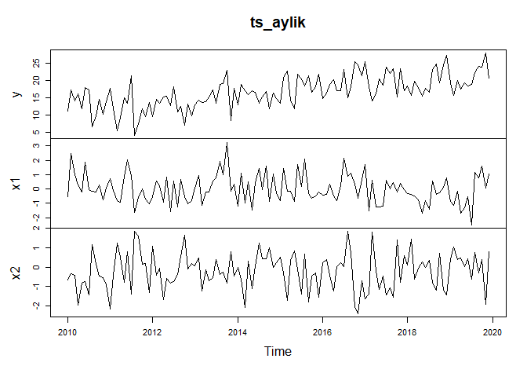

```r
plot(ts_aylik)
```

Benzer şekilde üç aylık bir `ts` nesnesi aşağıdaki gibi yaratılabilir:

```r
ts_quarterly <- ts(runif(8), start = c(2018, 1), frequency = 4)
ts_quarterly
```

```
##           Qtr1      Qtr2      Qtr3      Qtr4
## 2018 0.7304693 0.7870054 0.8954003 0.3331258
## 2019 0.8876747 0.6141378 0.7607281 0.5440350
```

`ts` nesnelerinin bir altkümesini oluşturmak istersek `window()` fonksiyonunu kullanabiliriz. Örneğin, `ts_aylik` veri setinden hareketle 2018m1’den son tarihe kadar olan kısmı alalım:

```r
ts_monthly_subset <- window(ts_aylik, start=c(2018,1))
ts_monthly_subset
```

```
##                 y          x1          x2
## Jan 2018 18.40797 -0.33324995  0.10869187
## Feb 2018 15.74612 -0.39793547  1.45290569
## Mar 2018 19.74570 -0.50115035 -0.61267109
## Apr 2018 18.01528 -0.77273822 -0.06516846
## May 2018 15.36078 -1.71239612  0.26570978
## Jun 2018 17.60987 -0.79921870 -0.01060245
## Jul 2018 16.49052 -1.41085475  0.33320645
## Aug 2018 23.21067  0.53275820 -0.79305213
## Sep 2018 24.64894 -0.39770077 -1.19191589
## Oct 2018 19.28710 -0.28435325  0.69395132
## Nov 2018 24.51503  0.12498413 -1.19316828
## Dec 2018 27.16400  0.78012669 -1.41040845
## Jan 2019 19.16921 -0.87559719  0.40811576
## Feb 2019 15.56407 -1.15936503  1.04478745
## Mar 2019 19.88641 -0.14586878  0.39343983
## Apr 2019 17.44377 -1.67842869  0.48269703
## May 2019 19.31902 -1.32258464  0.02858935
## Jun 2019 18.43350 -0.55887740  0.41441915
## Jul 2019 18.84263 -2.48978148 -0.61271368
## Aug 2019 22.35360  1.17918927  0.76866790
## Sep 2019 23.95577  0.79370484 -0.31469479
## Oct 2019 23.80681  1.60743480  0.37070328
## Nov 2019 27.92537  0.06594797 -1.93087451
## Dec 2019 20.57888  1.02900536  0.79631138
```

# 3 `zoo` object

`ts` sınıfının zayıf taraflarından biri zaman değişkeninin sadece nümerik olmasıdır. Aylık, üç aylık, yıllık gibi zaman serileri için bu önemli bir sorun oluşturmaz. Ancak düzensiz ölçümlü, kayıp gözlemli, saatlik, günlük gibi zaman serilerinin temsilinde problemler ortaya çıkabilir. Elimizdeki gözlemlerde kayıp değerler varsa sadece başlangıç ve bitişi tanımlayarak zaman serisini oluşturamayız.

`ts` sınıfına alternatif olarak geliştirilmiş çok sayıda paket mevcuttur. Bunlardan biri `zoo` paketi ve sınıfıdır. [Zeileis and Grothendieck (2005)](http://dx.doi.org/10.18637/jss.v014.i06). CRAN sayfası: [zoo: S3 Infrastructure for Regular and Irregular Time Series (Z’s Ordered Observations)](https://cran.r-project.org/web/packages/zoo/index.html).

```r
library(zoo)
n <- 10
dates <- seq(as.Date("2020-12-01"), length = n, by = "days")
dates
```

```
##  [1] "2020-12-01" "2020-12-02" "2020-12-03" "2020-12-04" "2020-12-05"
##  [6] "2020-12-06" "2020-12-07" "2020-12-08" "2020-12-09" "2020-12-10"
```

```r
x_zoo <- zoo(x = rnorm(n), order.by = dates)
x_zoo
```

```
##  2020-12-01  2020-12-02  2020-12-03  2020-12-04  2020-12-05  2020-12-06
##  0.82822485 -0.27596111  0.90011072  0.40052611 -2.43993993  1.70488277
##  2020-12-07  2020-12-08  2020-12-09  2020-12-10
## -0.35356859 -0.40279204 -0.01563910  0.04372756
```

```r
class(x_zoo)
```

```
## [1] "zoo"
```

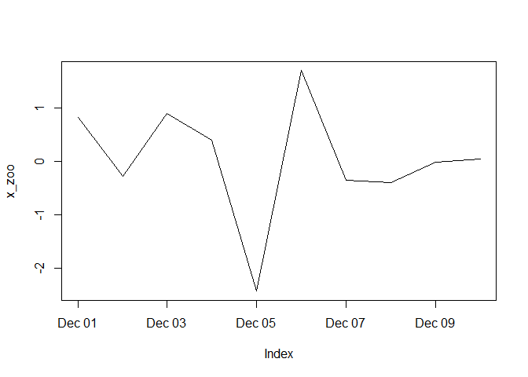

```r
plot(x_zoo)
```

Bir `ts` nesnesini `zoo` nesnesine dönüştürmek için `as.zoo()` fonksiyonu kullanılabilir. Tersi için `as.ts()` fonksiyonu kullanılabilir.

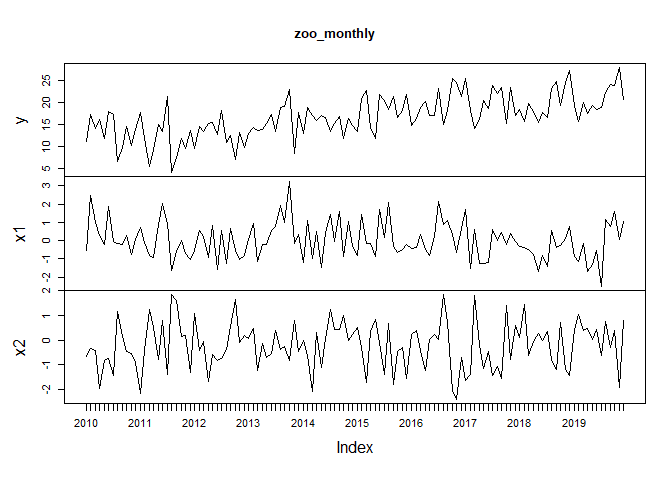

```r
zoo_monthly <- as.zoo(ts_aylik)
plot(zoo_monthly)
```

Örnek: `AirPassengers` ve `zoo` paketi:

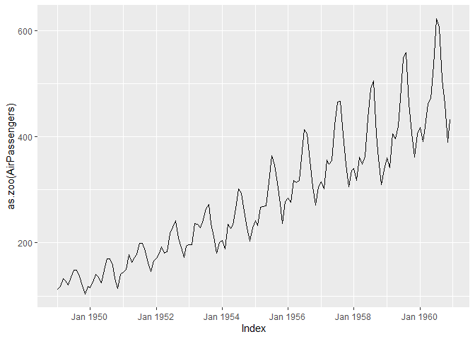

```r
plot(autoplot.zoo(as.zoo(AirPassengers)))
```

# 4 `xts` object

`xts` (Extensible Time Series) `zoo` nesnesinin özelliklerini genişletir. `xts` nesnesi ile POSIXct ve Date sınıflarını zaman değişkeni olarak kullanmak mümkündür. Daha fazla bilgi için CRAN sayfası: [xts: eXtensible Time Series](https://cran.r-project.org/web/packages/xts/index.html).

```r
library(xts)
xts_data1 <- xts(x = runif(5), order.by=Sys.Date()-1:5)
colnames(xts_data1) <- "var1"
xts_data1
```

```
##                 var1
## 2021-10-09 0.5986281
## 2021-10-10 0.4638573
## 2021-10-11 0.6464816
## 2021-10-12 0.7256413
## 2021-10-13 0.2013998
```

```r
# sunspots data
data("sunspots")
xts_sunspots <- as.xts(sunspots)
head(xts_sunspots)
```

```
##          [,1]
## Jan 1749 58.0
## Feb 1749 62.6
## Mar 1749 70.0
## Apr 1749 55.7
## May 1749 85.0
## Jun 1749 83.5
```

```r
class(xts_sunspots)
```

```
## [1] "xts" "zoo"
```

```r
periodicity(xts_sunspots)
```

```
## Monthly periodicity from Jan 1749 to Dec 1983
```

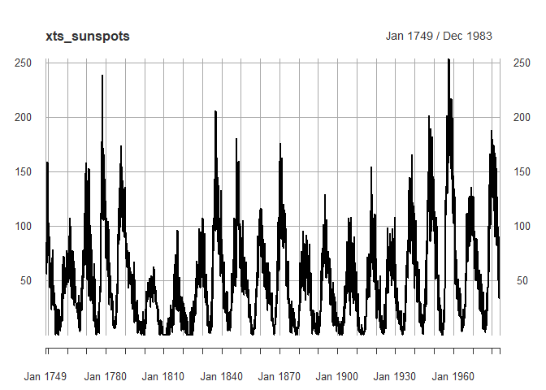

```r
plot(xts_sunspots)
```

Örnek: günlük veriler

```r
data("sample_matrix")
xts_daily <- as.xts(sample_matrix)
head(xts_daily)
```

```
##                Open     High      Low    Close
## 2007-01-02 50.03978 50.11778 49.95041 50.11778
## 2007-01-03 50.23050 50.42188 50.23050 50.39767
## 2007-01-04 50.42096 50.42096 50.26414 50.33236
## 2007-01-05 50.37347 50.37347 50.22103 50.33459
## 2007-01-06 50.24433 50.24433 50.11121 50.18112
## 2007-01-07 50.13211 50.21561 49.99185 49.99185
```

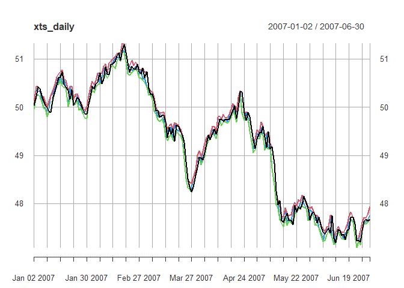

```r
plot(xts_daily)
```

# 5 `tsibble` object

Yakın tarihte geliştirilmiş başka bir alternatif `tsibble` nesnesidir. Bu nesne `tidyverts` paketler topluluğunun bir parçasıdır ve R. Hyndman tarafından geliştirilmiştir, bkz. [tidyverts](https://tidyverts.org/)

`tidyverts` dört paketten oluşur: `tsibble`, `fable`, `feasts`, ve `tsibbledata.` Bu paketler `tidyverse` paketleri ile uyumlu çalışacak şekilde tasarlanmıştır.[tidyverse](https://www.tidyverse.org/).

`tsibble` nesnesine ilişkin daha fazla bilgi için bkz. [tsibble: Tidy Temporal Data Frames and Tools](https://cran.r-project.org/web/packages/tsibble/index.html).

Ayrıca bkz. [Hyndman, R.J., & Athanasopoulos, G. (2019) Forecasting: principles and practice, 3rd edition, OTexts: Melbourne, Australia.](https://otexts.com/fpp3/)

Örnek: `tsibble` nesnesinin oluşturulması

```r
library(tsibble)
tsdata1 <- tsibble(year = 2017:2019,
                   var1 = c(100, 90, 105),
                   index = year)
tsdata1
```

```
## # A tsibble: 3 x 2 [1Y]
##    year  var1
##   <int> <dbl>
## 1  2017   100
## 2  2018    90
## 3  2019   105
```

Bir `tsibble` nesnesinin zamanı tanımlayan bir index değişkeni olmak zorundadır. Opsiyonel olarak başka anahtar (key) değişkenler de tanımlanabilir. Bu anahtar değişkenler panel veri setlerinin temsilinde kolaylık sağlayabilir. Yukarıdaki örnekte zaman indeksi year değişkenidir.

Örnek: Kişi başına GDP için iki-yıllık gözlemler, il düzeyinde veriler, iller: Istanbul, Ankara ve Izmir. Bu örnekte zaman indeksi `year` anahtar (key) değişkeni ise `province`’dir. Burada key değişkeni tanımlanmak zorunda çünkü belirli bir yılda çoklu gözlemler var (panel veri, longitudinal data).

```r
tsdata2 <- tsibble(year = c(rep(2017,3), rep(2018,3)),
                   province = rep(c("Istanbul", "Ankara", "Izmir"),2),
                   GDPpc = c(65195,51922,45102,76769,60249,54305),
                   index = year,
                   key = province
                   )
tsdata2
```

```
## # A tsibble: 6 x 3 [1Y]
## # Key:       province [3]
##    year province GDPpc
##   <dbl> <chr>    <dbl>
## 1  2017 Ankara   51922
## 2  2018 Ankara   60249
## 3  2017 Istanbul 65195
## 4  2018 Istanbul 76769
## 5  2017 Izmir    45102
## 6  2018 Izmir    54305
```

```r
index(tsdata2)
```

```
## year
```

```r
key(tsdata2)
```

```
## [[1]]
## province
```

Örnek: `tsibbledata` paketinde yer alan bir ülkeler-arası veri seti

```r
library(tsibbledata)
data("global_economy")
global_economy
```

```
## # A tsibble: 15,150 x 9 [1Y]
## # Key:       Country [263]
##    Country     Code   Year         GDP Growth   CPI Imports Exports Population
##    <fct>       <fct> <dbl>       <dbl>  <dbl> <dbl>   <dbl>   <dbl>      <dbl>
##  1 Afghanistan AFG    1960  537777811.     NA    NA    7.02    4.13    8996351
##  2 Afghanistan AFG    1961  548888896.     NA    NA    8.10    4.45    9166764
##  3 Afghanistan AFG    1962  546666678.     NA    NA    9.35    4.88    9345868
##  4 Afghanistan AFG    1963  751111191.     NA    NA   16.9     9.17    9533954
##  5 Afghanistan AFG    1964  800000044.     NA    NA   18.1     8.89    9731361
##  6 Afghanistan AFG    1965 1006666638.     NA    NA   21.4    11.3     9938414
##  7 Afghanistan AFG    1966 1399999967.     NA    NA   18.6     8.57   10152331
##  8 Afghanistan AFG    1967 1673333418.     NA    NA   14.2     6.77   10372630
##  9 Afghanistan AFG    1968 1373333367.     NA    NA   15.2     8.90   10604346
## 10 Afghanistan AFG    1969 1408888922.     NA    NA   15.0    10.1    10854428
## # ... with 15,140 more rows
```

Buradaki `global_economy` veri setinde time index `Year` ve key değişkeni `Country`’dir.

Yaygın kullanılan zaman formatları ve ilgili fonksiyonlar aşağıdaki tabloda özetlenmektedir. (Kaynak: [Hyndman and Athanasopoulos (2019) Forecasting: principles and practice, 3rd edition](https://otexts.com/fpp3/))

| **Interval** | **Class** | **Function** |
| --- | --- | --- |
| Annual | `integer`/`double` | `start:end` |
| Quarterly | `yearquarter` | `yearquarter()` |
| Monthly | `yearmonth` | `yearmonth()` |
| Weekly | `yearweek` | `yearweek()` |
| Daily | `Date`/`difftime` | `as_date()`, `ymd()` |
| Subdaily | `POSIXt`/`difftime`/`hms` | `as_datetime()` |

Mevcut bir zaman serisi nesnesi `tsibble` nesnesine dönüştürülebilir:

```r
library(tsibble)
library(tidyverse)
library(lubridate)
library(xts)
library(fpp3)
# use built-in daily data on closing prices from xts package
data("sample_matrix")
head(sample_matrix)
```

```
##                Open     High      Low    Close
## 2007-01-02 50.03978 50.11778 49.95041 50.11778
## 2007-01-03 50.23050 50.42188 50.23050 50.39767
## 2007-01-04 50.42096 50.42096 50.26414 50.33236
## 2007-01-05 50.37347 50.37347 50.22103 50.33459
## 2007-01-06 50.24433 50.24433 50.11121 50.18112
## 2007-01-07 50.13211 50.21561 49.99185 49.99185
```

```r
# convert sample_matrix into tibble and create a date variable
df1 <- tibble(date = rownames(sample_matrix),
              close = sample_matrix[,4]
              )
df1 <- df1 %>%
  mutate(date = lubridate::ymd(date))
df1
```

```
## # A tibble: 180 x 2
##    date       close
##    <date>     <dbl>
##  1 2007-01-02  50.1
##  2 2007-01-03  50.4
##  3 2007-01-04  50.3
##  4 2007-01-05  50.3
##  5 2007-01-06  50.2
##  6 2007-01-07  50.0
##  7 2007-01-08  50.0
##  8 2007-01-09  49.9
##  9 2007-01-10  50.0
## 10 2007-01-11  50.2
## # ... with 170 more rows
```

```r
tsibble_daily <- as_tsibble(df1, index = date)
tsibble_daily
```

```
## # A tsibble: 180 x 2 [1D]
##    date       close
##    <date>     <dbl>
##  1 2007-01-02  50.1
##  2 2007-01-03  50.4
##  3 2007-01-04  50.3
##  4 2007-01-05  50.3
##  5 2007-01-06  50.2
##  6 2007-01-07  50.0
##  7 2007-01-08  50.0
##  8 2007-01-09  49.9
##  9 2007-01-10  50.0
## 10 2007-01-11  50.2
## # ... with 170 more rows
```

Buradan hareketle ay içindeki ortalama kapanış değerlerini hesaplayarak bir aylık veri seti oluşturabiliriz. Bunun için önce yeni bir değişken oluşturalım ve buna `year_month` ismini verelim, `tsibble::yearmonth()`.

```r
tsibble_monthly <- tsibble_daily %>%
  mutate(year_month = yearmonth(date))
tsibble_monthly
```

```
## # A tsibble: 180 x 3 [1D]
##    date       close year_month
##    <date>     <dbl>      <mth>
##  1 2007-01-02  50.1   2007 Jan
##  2 2007-01-03  50.4   2007 Jan
##  3 2007-01-04  50.3   2007 Jan
##  4 2007-01-05  50.3   2007 Jan
##  5 2007-01-06  50.2   2007 Jan
##  6 2007-01-07  50.0   2007 Jan
##  7 2007-01-08  50.0   2007 Jan
##  8 2007-01-09  49.9   2007 Jan
##  9 2007-01-10  50.0   2007 Jan
## 10 2007-01-11  50.2   2007 Jan
## # ... with 170 more rows
```

Yeni veri seti `tsibble_monthly`’nin time indeksi `date` değişkenidir. Gruplama fonksiyonu `index_by()` ile özet istatistikleri hasaplayabiliriz. Bunun kullanımı `dplyr` paketindeki `group_by()` fonksiyonu ile aynıdır.

```r
tsibble_monthly2 <- tsibble_monthly %>%
  index_by(year_month) %>%
  summarize(close_avr = mean(close),
            count = n())
tsibble_monthly2
```

```
## # A tsibble: 6 x 3 [1M]
##   year_month close_avr count
##        <mth>     <dbl> <int>
## 1   2007 Jan      50.2    30
## 2   2007 Feb      50.8    28
## 3   2007 Mar      49.5    31
## 4   2007 Apr      49.6    30
## 5   2007 May      48.3    31
## 6   2007 Jun      47.5    30
```

Günlük verilerin grafiği:

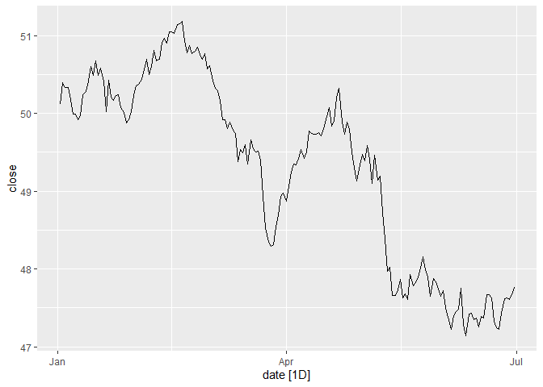

```r
tsibble_daily %>% autoplot(close)
```

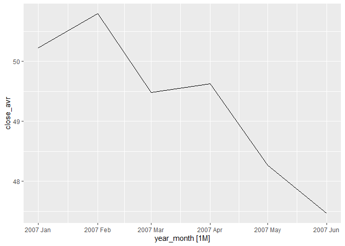

```r
tsibble_monthly2 %>% autoplot(close_avr)
```

# 6 `quantmod` ile finansal verilerin indirilmesi

```r
# install.packages("quantmod")
library(quantmod)
```

Apple hisse senedinin günlük verilerini 01-01-2018-31-08-2021 arasına kapsayacak şekilde indirelim:

```r
# yil-ay-gün
getSymbols("AAPL", from='2018-01-01',to='2021-08-31')
```

[output not shown]

```
## [1] "AAPL"
```

`AAPL` bir `xts` nesnesi olarak tanımlıdır.

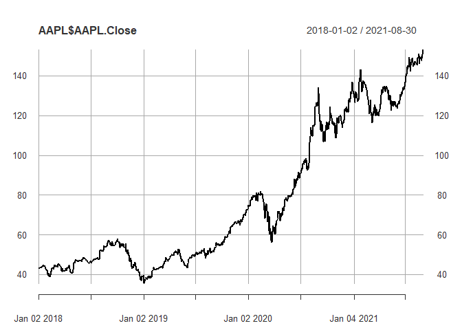

```r
# APPLE kapanış değerleri
plot(AAPL$AAPL.Close)
```

`quantmod:ChartSeries()` fonksiyonu ile görselleştirme:

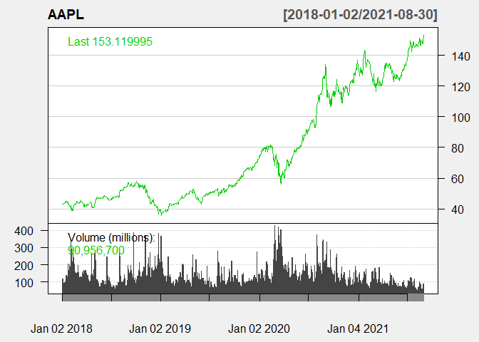

```r
chartSeries(AAPL,
            type="line",
            theme=chartTheme('white'))
```

Sadece 2020 yılı:

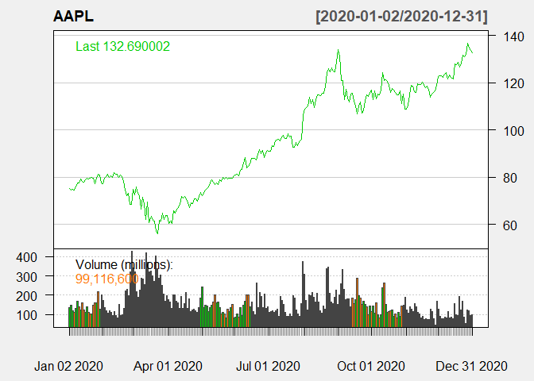

```r
chartSeries(AAPL,
            type="line",
            subset='2020',
            theme=chartTheme('white'))
```

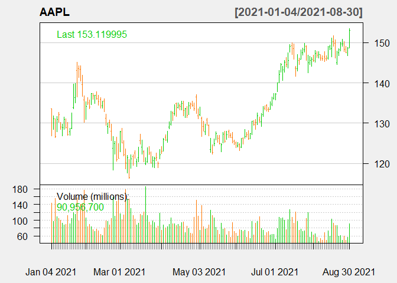

```r
chartSeries(AAPL,
            type="bar",
            subset="2021",
            theme=chartTheme('white'))
```

Candle stick plot:

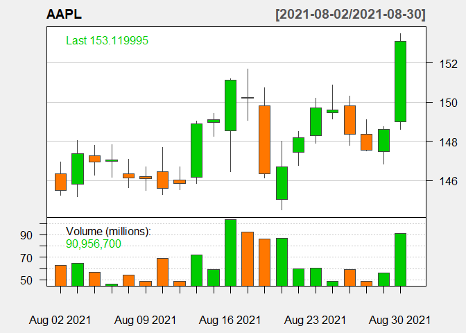

```r
chartSeries(AAPL,
            type="candlesticks",
            subset="2021-08",
            theme=chartTheme('white'))
```